# Notebook Instructions for M2 SSD HAX004X Dirty Data

Author

David Métivier

Published

January 5, 2026

In this course, you will learn about statistical methods for ``dirty data’’. At the end of each lecture, you will be given a small assignment. The goal will be for you to

- Manipulate real datasets with missing values, outliers, or other imperfections.
- Apply the statistical methods covered in the lecture and/or try your own to analyze the data.
- Produce a simple scientific report documenting your work.

You will return Quarto notebooks (`.qmd` + rendered `.html`) containing your code, results, plots, and explanations.

**Important**

Manipulating data frames is a key skill for data analysis and data science. You must know how to do it in your language of choice (R, Julia, Python, etc.). Transforming data, filtering rows, grouping by categories, and summarizing statistics are common tasks.

# Instructions for Quarto notebooks report

Quarto notebooks allow you to combine code, results, plots, and narrative text in a single document. It supports multiple programming languages, including Julia and R.

## Quarto Installation

Go to https://quarto.org/docs/get-started/ to install Quarto on your system.

It can be used within VSCode with the Quarto extension installed and RStudio & Jupyter (I did not test these options).

**WarningUpdate!**

If you have already Quarto installed, make sure to update to the latest version to ensure compatibility with all features.

## Guidelines for your notebook report

To create your notebook report, follow these steps:

- Create a new Quarto notebook file -> just create a file with the extension `.qmd`.
- Fill the yaml header with your name and date as shown above.
- Use Markdown (e.g., headings, lists) to explain your code and results.
- Use code chunks to include your Julia and/or R code.
- Add plots and tables as needed to illustrate your findings.
- Render the notebook to HTML using Quarto. The output file should be named `notebook_yourname1_yourname2_CMX.html` and Quarto `notebook_yourname1_yourname2_CMX.qmd` where X is the course number when the exercise was given.
- Submit both the `.qmd` and the rendered `.html` files (with the folder) on Moodle.

# Julia

## Installation

Details can be found at https://julialang.org/downloads/ but here are quick instructions. The following will

- install `juliaup`
- install the latest stable Julia version
- add Julia to your system path

**WarningUpdate!**

If you have already Julia installed, make sure to install it with the following procedure and update to the latest version to ensure compatibility with all features.

### Windows

With the Windows store app:

[interactive chart not shown]

or directly

```bash
winget install --name Julia --id 9NJNWW8PVKMN -e -s msstore
```

### macOS & Linux

Just run the following in your terminal:

```bash
curl -fsSL https://install.julialang.org | sh
```

## Starting Julia

You can start Julia from your terminal by typing `julia`. You can also use Julia within VSCode with the Julia extension installed.

Here are some useful links to get started with Julia (watch out, some tutorials on internet may be outdated):

- [Official Julia Documentation](https://docs.julialang.org/): very comprehensive and well-maintained but might not be the best to begin.
- [Introduction to Julia for R users](https://nrennie.rbind.io/blog/introduction-julia-r-users/). It is not perfect (from a Julia perspective) but a good start if you know R.
- [Modern Julia Workflows](https://modernjuliaworkflows.org/): quite complete and up-to-date introduction to Julia programming and ecosystem. (But not a real tutorial)

**TipPackage Environment**

To make your code reproducible, it is important to manage package versions properly. **It is true for every programming language.**

In Julia, the project environment = package names + versions and dependence is defined in the `Project.toml` and `Manifest.toml` files in this folder.

In R, I am not sure how to manage environments properly.

To activate the environment defined in this folder, run the following code chunk at the beginning of your Julia notebook (it is not mandatory but recommended):

```julia
cd(@__DIR__) # cd in notebook folder
import Pkg
Pkg.activate("."); # activate the environment in this folder
```

```
  Activating project at `C:\Users\metivier\Dropbox\Apps\Overleaf\Cours_M2_HAX004X_Bertrand_David\notebook`
```

## Using R from Julia

**TipUsing R, Python and C from Julia**

Using packages such as `RCall.jl` and `PythonCall.jl`, Julia can seamlessly call R and Python code from within Julia scripts or notebooks. C code can be compiled into shared libraries and called using Julia’s `ccall` interface.

```julia
# import PythonCall #if you want to test Python version
import RCall
```

See for example [this notebook](https://dmetivie.github.io/Pluto_export/SWG_coding_challenges/Talk_DM_quarto.html) using R and Julia (and C) together with speed comparison for a Hidden Markov Model.

# Example with Julia and weather data

Here is a tiny example of data (coming from a Montpellier weather station) manipulation using [DataFrames.jl](https://dataframes.juliadata.org/stable/) and [DataFramesMeta.jl](https://juliadata.github.io/DataFramesMeta.jl/stable/) packages in Julia.

**TipData manipulation in Julia**

Here we use `DataFramesMeta.jl` which provides a convenient syntax for data manipulation. To get something very similar to the **tidyverse syntax** in R check out the [`Tidier.jl`](https://github.com/TidierOrg) ecosystem with TidierData.jl for data manipulation.

## Loading packages

```julia
using DataFrames, CSV, Downloads, Dates
using DataFramesMeta, StatsBase
```

## Loading data

The file contains daily weather data from a weather station in Montpellier (France).

```julia
url = "https://raw.githubusercontent.com/dmetivie/StochasticWeatherGenerator.jl/master/weather_files/TX_STAID002207.txt"
http_response = Downloads.download(url) # download file from a GitHub repo
df = CSV.read(http_response, DataFrame; normalizenames=true, dateformat="yyyymmdd", types=Dict(:DATE => Date), header=21)
df[1:20, :] # show first 20 rows
```

20×5 DataFrame

| Row | STAID Int64 | SOUID Int64 | DATE Date | TX Int64 | Q_TX Int64 |
| --- | --- | --- | --- | --- | --- |
| 1 | 2207 | 6448 | 1946-01-01 | 58 | 0 |
| 2 | 2207 | 6448 | 1946-01-02 | 96 | 0 |
| 3 | 2207 | 6448 | 1946-01-03 | 95 | 0 |
| 4 | 2207 | 6448 | 1946-01-04 | 76 | 0 |
| 5 | 2207 | 6448 | 1946-01-05 | 70 | 0 |
| 6 | 2207 | 6448 | 1946-01-06 | 108 | 0 |
| 7 | 2207 | 6448 | 1946-01-07 | 110 | 0 |
| 8 | 2207 | 6448 | 1946-01-08 | 90 | 0 |
| 9 | 2207 | 6448 | 1946-01-09 | 130 | 0 |
| 10 | 2207 | 6448 | 1946-01-10 | 133 | 0 |
| 11 | 2207 | 6448 | 1946-01-11 | 146 | 0 |
| 12 | 2207 | 6448 | 1946-01-12 | 150 | 0 |
| 13 | 2207 | 6448 | 1946-01-13 | 130 | 0 |
| 14 | 2207 | 6448 | 1946-01-14 | 80 | 0 |
| 15 | 2207 | 6448 | 1946-01-15 | 32 | 0 |
| 16 | 2207 | 6448 | 1946-01-16 | 44 | 0 |
| 17 | 2207 | 6448 | 1946-01-17 | 62 | 0 |
| 18 | 2207 | 6448 | 1946-01-18 | 71 | 0 |
| 19 | 2207 | 6448 | 1946-01-19 | 97 | 0 |
| 20 | 2207 | 6448 | 1946-01-20 | 70 | 0 |

## Monthly mean and standard deviation of daily temperature

```julia
factor = 0.1 # to convert from tenths of °C to °C
df_month = @chain df begin
    @subset(:Q_TX .!= 9) # remove missing
    @transform(:MONTH = month.(:DATE)) # add month column
    @by(:MONTH, :MONTHLY_MEAN = mean(:TX) * factor, :MONTHLY_STD = std(:TX) * factor) # groupby MONTH + takes the mean/std in each category
end
```

12×3 DataFrame

| Row | MONTH Int64 | MONTHLY_MEAN Float64 | MONTHLY_STD Float64 |
| --- | --- | --- | --- |
| 1 | 1 | 11.4453 | 3.61758 |
| 2 | 2 | 12.7332 | 3.67788 |
| 3 | 3 | 15.4664 | 3.41305 |
| 4 | 4 | 18.0968 | 3.24402 |
| 5 | 5 | 21.7896 | 3.4346 |
| 6 | 6 | 26.0935 | 3.49832 |
| 7 | 7 | 29.0241 | 3.00726 |
| 8 | 8 | 28.3806 | 2.90772 |
| 9 | 9 | 24.9303 | 2.98281 |
| 10 | 10 | 20.4157 | 3.1212 |
| 11 | 11 | 15.2892 | 3.34882 |
| 12 | 12 | 12.1186 | 3.40215 |

Plotting with `CairoMakie.jl` package:

```julia
using CairoMakie
```

**TipPlotting in Julia**

In Julia, several plotting packages are available, such as `Plots.jl`, `Makie.jl`. Each support various backends for static or interactive plots. `CairoMakie.jl` provides high-quality static plots.

For ggplot2-like plotting in Julia, you can use the [`TidierPlots.jl`](https://github.com/TidierOrg/TidierPlots.jl) package, which offers a grammar of graphics approach with a syntax very close to ggplot2 in R.

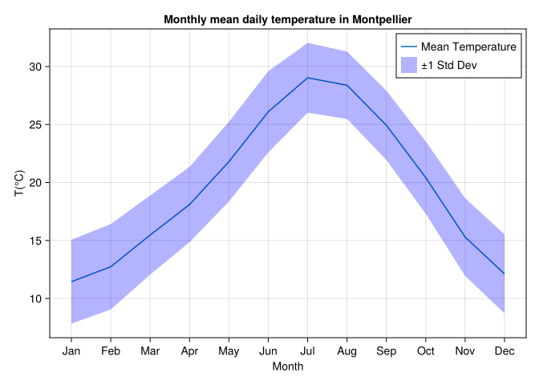

```julia
fig = Figure()
ax = Axis(fig[1, 1]; xlabel="Month", title="Monthly mean daily temperature in Montpellier", ylabel="T(°C)", xticks=(1:12, monthabbr.(1:12)))
lines!(ax, 1:12, df_month.MONTHLY_MEAN, label="Mean Temperature")
band!(ax, 1:12, df_month.MONTHLY_MEAN .- df_month.MONTHLY_STD, df_month.MONTHLY_MEAN .+ df_month.MONTHLY_STD, color=(:blue, 0.3), label="±1 Std Dev")
axislegend(ax; position=:rt)
fig
```

## Global warming trend

Here we consider the yearly mean temperature and a simple linear trend to illustrate the global warming trend.

```julia
df_trend = @chain df begin
    @subset(:Q_TX .!= 9) # remove missing
    @transform(:YEAR = year.(:DATE)) # add year column
    @subset(:YEAR .< 2025) # The data stops in July 2025.
    @by(:YEAR, :YEARLY_MEAN = mean(:TX) * factor) # groupby YEAR
end;
```

For illustration, we consider a simple linear trend fitted “by hand”. Of course one could use optimization to select the yearly offset and slope as well as considering other forms of trend.

```julia
f_trend(x) = 19 + 0.05 * ifelse(x < 1980, 0, x - 1980) # i.e. ≃2°C warming in 40 years in Montpellier
```

```
f_trend (generic function with 1 method)
```

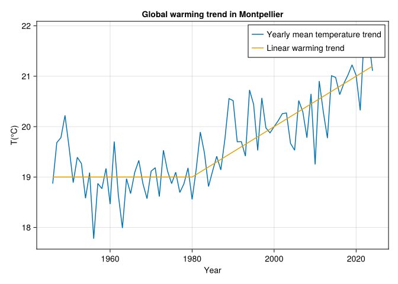

```julia
begin
    fig = Figure()
    ax = Axis(fig[1, 1]; xlabel="Year", title="Global warming trend in Montpellier", ylabel="T(°C)")
    lines!(ax, df_trend.YEAR, df_trend.YEARLY_MEAN, label="Yearly mean temperature trend")
    lines!(ax, df_trend.YEAR, f_trend.(df_trend.YEAR), label="Linear warming trend")
    axislegend(ax; position=:rt)
    fig
end
```